# Join metadata with GCP files

Bria Long

2024-10-25

# Setup

```r
library(tidyverse)
library(here)
library(googlesheets4)
library(lubridate)
library(ggthemes)
library(knitr)
```

# Load family demographics

IDENTIFIABLE (!) with birthdate if you get it from the source; that bit is commented out now.

Here we are using a deidentified version to check rough ages

```r
families = read_csv(file=here::here('data/demographics_2025.csv')) %>%
  as_tibble() %>%
  filter(study_name == 'BabyView') %>% # no pilots
  select(sid, date_birth, ethnicity, gender, num_lang, parent_ed) %>%
  rename(birthdate = date_birth) %>%
  mutate(subject_id = paste0('00',sid)) %>%
  filter(!is.na(subject_id))
```

```
## ──────────────────────────────────────────────────────── Delimiter: "," chr
## (11): experimenter, location, study_name, sid, date_test, date_birth, hi... dbl
## (5): protocol, weeks_old, months_old, num_lang, parent_ed lgl (12): RA, ...18,
## ...19, ...20, ...21, ...22, ...23, ...24, ...25, ...26,...
```

```r
# We collected data from `r length(unique(families$subject_id))`.
# In our sample, `r sum(families$num_lang>1)` children are exposed to more than one language.

families_short <- families %>%
  select(subject_id, birthdate, num_lang) %>%
  mutate(num_lang = as.numeric(num_lang))
```

```r
# families_deidentified <- families %>%
  # select(subject_id, birthdate, num_lang) %>%
  # mutate(birthdate = mdy(birthdate)) %>%
  # mutate(birthdate = round_date(birthdate, unit="month"))

# write_csv(families_deidentified, file=here::here('data/release_2.0/subids_deidentified.csv'))
```

Load in deidentified info

```r
# families_short = read_csv(file=('subids_deidentified.csv'))
```

## Load bv main – ongoing

```r
# ongoing data collection
ongoing_session_durations <- read_sheet('https://docs.google.com/spreadsheets/d/1mAti9dBNUqgNQQIIsnPb5Hu59ovKCUh9LSYOcQvzt2U/edit?gid=754020357#gid=754020357',sheet='Ongoing_data_collection') %>%
  filter(Status=="Uploaded") %>%
  select(-Notes) %>% # causing join errors because incompatible types
  select(subject_id, video_id,  Upload_fname, Date, `Blackout Portions`, Duration) %>%
  rename(exclude = `Blackout Portions`) %>%
  left_join(families_short, by=c('subject_id')) %>%
  mutate(cohort = 'ongoing')  %>%
  mutate(video_name = str_split_fixed(Upload_fname, '.zip',2)[,1]) %>%
  # Fix the date column, which is in a list for this sheet but not all
  filter(map_lgl(Date, ~ !is.null(.x)))  %>%
  mutate(date_column = map_chr(Date, ~ as.character(.x[1])))  %>%
  mutate(date_tested = ymd(date_column))  %>%
  select(-Date, -date_column) %>%
  mutate(video_name = str_replace_all(video_name, "PM", "pm"),
         video_name = str_replace_all(video_name, "AM", "am"))
```

```
## ! Using an auto-discovered, cached token.
```

```
##   To suppress this message, modify your code or options to clearly consent to
##   the use of a cached token.
```

```
##   See gargle's "Non-interactive auth" vignette for more details:
```

```
## ℹ The googlesheets4 package is using a cached token for 'brlong@ucsd.edu'.
```

```
## ✔ Reading from "BabyView Session Tracking".
```

```
## ✔ Range ''Ongoing_data_collection''.
```

```r
## Not missing video names
# sum(is.na(ongoing_session_durations$Upload_fname))

# Missing dates?
sum(is.na(ongoing_session_durations$date_tested))
```

```
## [1] 8
```

## Load bv main – release 1

```r
# release 1
release_1_session_durations <- read_sheet('https://docs.google.com/spreadsheets/d/1mAti9dBNUqgNQQIIsnPb5Hu59ovKCUh9LSYOcQvzt2U/edit?gid=1883822719#gid=1883822719', sheet='Main_Release_1_Corrected_test') %>%
  filter(Vid_In_Storage_Bucket=="Y") %>% # filter to uploadeed vids
  select(subject_id, video_id, old_name, Date, `Blackout Portions`, Duration, `grace notes`) %>%
  rename(exclude = `Blackout Portions`) %>% # tag when there was anything to be excluded
  rename(changed = `grace notes`) %>%
  left_join(families_short, by=c('subject_id')) %>%
  mutate(cohort = 'release_1') %>%
  mutate(low_res = str_detect(old_name,'.LRV')) %>%
  mutate(video_name = str_split_fixed(old_name, "\\.MP4|\\.LRV|\\.ZIP", n = 2)[, 1]) %>%
  # Fix the date column, which is in a list for this one
  mutate(date_tested = mdy(Date)) %>%
  mutate(Duration = as.numeric(Duration)) %>%
  mutate(video_name = str_replace_all(video_name, "PM", "pm"),
         video_name = str_replace_all(video_name, "AM", "am"))
```

```
## ✔ Reading from "BabyView Session Tracking".
```

```
## ✔ Range ''Main_Release_1_Corrected_test''.
```

```r
## Stil missing 1090 video names as of 10pm on 2/10/25
sum(is.na(release_1_session_durations$video_name))
```

```
## [1] 7
```

```r
sum(is.na(release_1_session_durations$date_tested))
```

```
## [1] 46
```

## Ego-single child, releases 1/2

```r
# release 1
luna_release_1_session_durations <- read_sheet('https://docs.google.com/spreadsheets/d/1mAti9dBNUqgNQQIIsnPb5Hu59ovKCUh9LSYOcQvzt2U/edit?gid=1883822719#gid=1883822719', sheet='Luna_V1_Corrected') %>%
  filter(Vid_In_Storage_Bucket=="Y") %>%
  select(subject_id, video_id, Upload_fname, Date, `Blackout Portions`, Duration) %>%
  rename(exclude = `Blackout Portions`) %>% # tag when there was anything to be excluded
  left_join(families_short, by=c('subject_id')) %>%
  mutate(cohort = 'ego_single') %>%
  mutate(video_name = str_split_fixed(Upload_fname, '.zip',2)[,1]) %>%
  # Fix the date column, which is in a list for this one
  filter(map_lgl(Date, ~ !is.null(.x)))  %>%
  mutate(date_column = map_chr(Date, ~ as.character(.x[1])))  %>%
  mutate(date_tested = ymd(date_column))  %>%
  mutate(Duration = as.numeric(Duration)) %>%  # weird in `test` sheet
  select(-Date)
```

```
## ✔ Reading from "BabyView Session Tracking".
```

```
## ✔ Range ''Luna_V1_Corrected''.
```

```r
## Not missing luna names
sum(is.na(luna_release_1_session_durations$Upload_fname))
```

```
## [1] 0
```

```r
sum(is.na(luna_release_1_session_durations$date_tested))
```

```
## [1] 2
```

```r
# release 2 luna
luna_release_2_session_durations <- read_sheet('https://docs.google.com/spreadsheets/d/1mAti9dBNUqgNQQIIsnPb5Hu59ovKCUh9LSYOcQvzt2U/edit?gid=1883822719#gid=1883822719', sheet='Luna_Round_2_Ongoing') %>%
  filter(Status=="Uploaded") %>%
  select(subject_id, video_id, Upload_fname, Date, `Delete?`, Duration) %>%
  rename(exclude = `Delete?`) %>% # tag when there was anything to be excluded
  left_join(families_short, by=c('subject_id')) %>%
  mutate(cohort = 'ego_single') %>%
  mutate(video_name = str_split_fixed(Upload_fname, '.zip',2)[,1]) %>%
  # Fix the date column
  mutate(date_column = ymd(Date)) %>%
  mutate(date_tested = ymd(date_column))  %>%
  select(-Date, -date_column)
```

```
## ✔ Reading from "BabyView Session Tracking".
```

```
## ✔ Range ''Luna_Round_2_Ongoing''.
```

```r
sum(is.na(luna_release_2_session_durations$Upload_fname))
```

```
## [1] 0
```

```r
# all bing
bing_sessions <- read_sheet('https://docs.google.com/spreadsheets/d/1mAti9dBNUqgNQQIIsnPb5Hu59ovKCUh9LSYOcQvzt2U/edit?gid=1883822719#gid=1883822719', sheet='Bing') %>%
  filter(Vid_In_Storage_Bucket=="Y") %>%
  select(subject_id, video_id, Upload_fname, Date, `Blackout Portions`, Duration) %>%
  rename(exclude = `Blackout Portions`) %>% # tag when there was anything to be excluded
  left_join(families_short, by=c('subject_id')) %>%
  mutate(cohort = 'bing') %>%
  mutate(video_name = str_split_fixed(Upload_fname, '.zip',2)[,1]) %>%
  # Fix the date column, which is in a list for this one
  filter(map_lgl(Date, ~ !is.null(.x)))  %>%
  mutate(date_column = map_chr(Date, ~ as.character(.x[1])))  %>%
  mutate(date_tested = ymd(date_column))   %>%
  select(-Date, -date_column)
```

```
## ✔ Reading from "BabyView Session Tracking".
```

```
## ✔ Range ''Bing''.
```

```r
## Not missing bing names
sum(is.na(bing_sessions$Upload_fname))
```

```
## [1] 0
```

## Join all together

```r
all_sessions <- release_1_session_durations %>%
  full_join(ongoing_session_durations) %>%
  full_join(luna_release_1_session_durations) %>%
  full_join(luna_release_2_session_durations) %>%
  full_join(bing_sessions)
```

[output not shown]

# Join metadata with filenames from GCP pulls

```r
to_join <- all_sessions %>%
  arrange(video_name) %>%
  mutate(filename = video_name)
```

Here’s the file list from Khais’ pull on GCP, try to join

```r
joined_release_2 <- read_csv(file = here::here('data/included_videos.csv'))   %>%
  mutate(filename = str_replace_all(filename, regex("n\\.a", ignore_case = TRUE), "NA")) %>%
  mutate(filename = str_replace_all(filename, regex("\\bna\\b", ignore_case = TRUE), "NA")) %>%
  mutate(filename = str_replace_all(filename, "PM", "pm"),
         filename = str_replace_all(filename, "AM", "am")) %>%
  left_join(to_join)
```

Get date information from week range

```r
wrong_dates <- joined_release_2 %>%
  filter(date_tested < ymd("2019-01-01")) %>%
  mutate(date_tested = NA)

wrong_dates_2 <- joined_release_2 %>%
  filter(date_tested > ymd("2027-01-01")) %>%
  mutate(date_tested = NA)

to_fix <- joined_release_2  %>%
  filter(cohort != 'ego-singlechild') %>%
  filter(is.na(date_tested)) %>%
  full_join(wrong_dates_2) %>%
  full_join(wrong_dates) %>%
  mutate(date_range_inferred = str_split_fixed(filename, '_', 5)[,3]) %>%
  mutate(date_inferred = str_split_fixed(date_range_inferred,'-',2)[,1]) %>%
  mutate(date_inferred = mdy(date_inferred)) %>%
  mutate(date_tested = coalesce(date_tested,date_inferred)) %>%
  select(-date_inferred, -date_range_inferred)
```

```
## exclude, Duration, changed, birthdate, num_lang, cohort, low_res, video_name,
## date_tested, Upload_fname, date_column)`
## exclude, Duration, changed, birthdate, num_lang, cohort, low_res, video_name,
## date_tested, Upload_fname, date_column)`
```

```r
with_new_dates <-  joined_release_2 %>%
  filter(!filename %in% to_fix$filename) %>%
  full_join(to_fix) %>%
  mutate(age_in_days_during_video = as.numeric(difftime(ymd(date_tested), mdy(birthdate), units='days'))) %>%
  select(-birthdate)
```

```
## exclude, Duration, changed, birthdate, num_lang, cohort, low_res, video_name,
## date_tested, Upload_fname, date_column)`
```

```r
merged <- with_new_dates %>%
  filter(!is.na(subject_id))%>%
  filter(is.na(exclude)) %>%
  mutate(age_in_months = age_in_days_during_video/30.44) %>%
  rename(duration = Duration) %>%
  distinct(filename, subject_id, video_id, duration, num_lang, cohort, video_name, filename, age_in_months, date_tested)


library(assertthat)
assert_that(sum(merged$age_in_months<0)==0)
```

```
## [1] TRUE
```

```r
assert_that(sum(merged$age_in_months>50)==0)
```

```
## [1] TRUE
```

```r
write_csv(merged, file=here::here('data/merged_data_descriptives.csv'))
```

```r
summary_by_cohort <- merged %>%
  filter(!is.na(subject_id))  %>%
  group_by(cohort) %>%
  summarize(num_files = length(unique(filename))) %>%
  kable()
```

```r
no_merge <- joined_release_2 %>%
  filter(is.na(subject_id))  %>%
  select(filename)

write_csv(no_merge, file=here::here('data/no_merge_vids.csv'))
```

We have 5014 matched videos out of the 5041 that were in the pull of the dataset. We are still missing information about 2 files, we excluded 25 videos that had sensitive information. We had 5049 files and with 5041 unique filenames, which means there were a few accidental duplicate videos.

## Save

```r
write_csv(merged, file=here::here('data/merged_dataset_with_descriptives.csv'))
```

## Make a list of the files we need to make sure not to include

```r
to_delete_release2 <- joined_release_2 %>%
  filter(!is.na(exclude)) %>%
  select(filename, subject_id, date_tested, Duration, cohort, exclude) %>%
  group_by(cohort)

# these videos were recorded but then manually deleted and are not in the release or in the raw/storage buckets
to_delete_from_spreadhseet <- all_sessions %>%
  filter(!is.na(exclude)) %>%
  anti_join(to_delete_release2 %>% rename(vid_name = filename))
# these were given to the team before merging was done,
blackout_first_round = read_csv(file=here::here('data/to_delete_blackout_vids.csv')) %>%
  mutate(first_blackout = TRUE)
# here are all the files that need to be deleted
to_delete_release2 <- joined_release_2 %>%
  filter(!is.na(exclude)) %>%
  select(filename, subject_id, date_tested, Duration, cohort, exclude) %>%
  left_join(blackout_first_round)
write_csv(to_delete_release2, file=here::here('data/to_delete_blackout_vids_post_match.csv'))
```

# Subsample videos for whisper transcripts

Get the videos that we manually annotated, do some annoying joining because the video names have changed

```r
sampled_release_1 <- read_csv(file=here::here('data/to_sample_for_whisper_may2024.csv')) %>%
  select(filename) %>%
  mutate(filename = str_split_fixed(filename, '.MP4',2)[,1]) %>%
  mutate(subject_id = str_split_fixed(filename, '_',4)[,1]) %>%
  mutate(video_id = str_split_fixed(filename, '_',4)[,2]) %>%
  rename(release_1_filename = filename) %>%
  left_join(merged, by=c('subject_id','video_id'))
```

There are 19 videos that we can’t match, but that’s not too bad in the scheme of things.

```r
no_merge_whisper <- sampled_release_1 %>%
  filter(is.na(filename))
```

# Whisper video sampling

```r
release_1_whisper <- sampled_release_1 %>%
  filter(!is.na(filename)) %>% # 19 couldn't match
  filter(num_lang==1) %>%
  group_by(subject_id) %>%
  summarize(num_vids = length(unique(filename)))

release_1_whisper_by_vid <- sampled_release_1 %>%
  filter(!is.na(filename)) %>% # 19 couldn't match
  filter(num_lang==1)
```

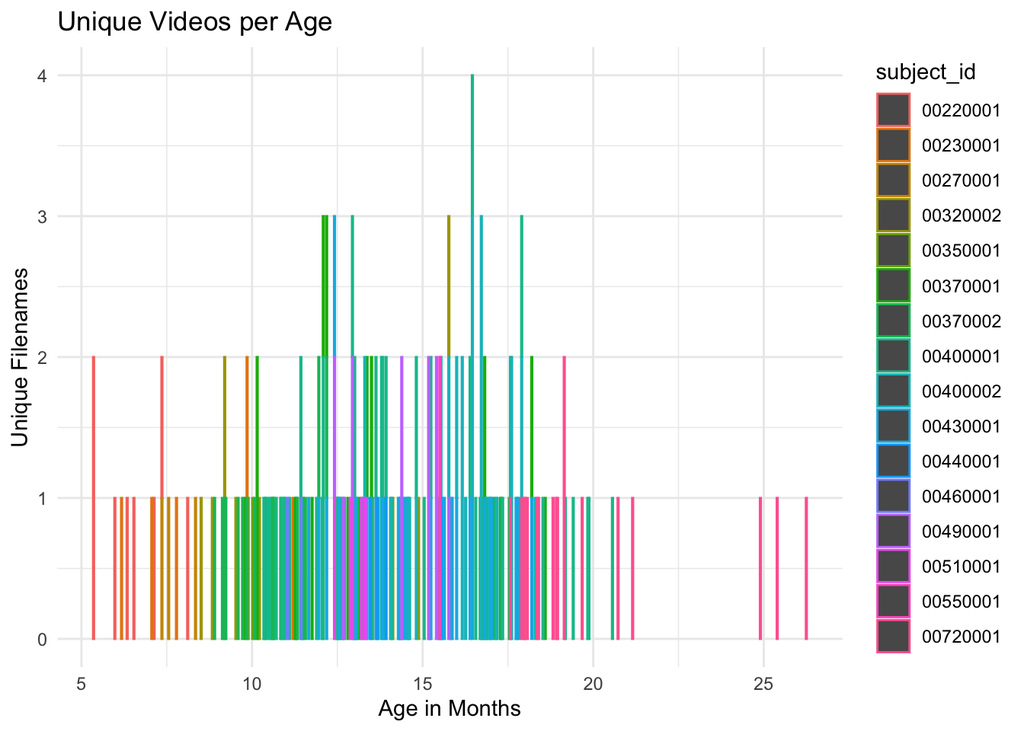

```r
# Summarize data to count unique filenames per subject and age bin
plot_data <- release_1_whisper_by_vid %>%
  group_by(subject_id, age_in_months) %>%
  summarise(unique_filenames = n_distinct(filename), .groups = "drop")

# Create the plot
ggplot(plot_data, aes(x = age_in_months, y = unique_filenames, col = subject_id)) +
  geom_col() +  # Use geom_col() instead of geom_bar(stat="identity")
  labs(x = "Age in Months", y = "Unique Filenames", title = "Unique Videos per Age") +
  theme_minimal()
```

## Get videos to annotate

And then save out the csv

```r
 to_sample <- merged %>%
  filter(duration>(3*60)) %>% # only videos 3 mins or longer
  filter(cohort!="ego_single") %>% # not luna
  filter(num_lang==1) %>% # monolingual
  filter(!subject_id %in% release_1_whisper$subject_id) %>% # haven't sampled before
   group_by(subject_id) %>%
   arrange(age_in_months) %>%
   mutate(vid_index = row_number()) %>%
   filter(vid_index%%6==0) %>%
   mutate(start_time = duration/2) %>%
   mutate(end_time = start_time + 30) %>%
   arrange(subject_id, age_in_months)

write_csv(to_sample, file=here::here('data/to_sample_for_whisper_release2.csv'))
```